# Rugby-try-analysis

Rugby-try-analysis Josh Drummond 11/04/2020

## Overview

This activity provides you with the opportunity to practice and work through a reproducible data analysis project. In this activity we will be exploring rugby try scoring data.

## Load required packages

```r
library(tidyverse) # include all required packages at the start
```

## Data source

The data set used in this activity has been saved in the 2017_super-rugby_try-source-data.csv file.

## Read data

```r
# read in the data
# data dir should be in the working dir
df <- read_csv("2017_super-rugby_try-source-data.csv")
```

## Checking the data

Check the structure of the data file using `str()`:

```r
str(df)
```

```
## Classes 'spec_tbl_df', 'tbl_df', 'tbl' and 'data.frame': 943 obs. of  17 variables:
##  $ try_no          : num  1 2 3 4 5 6 7 8 9 10 ...
##  $ round_no        : num  1 1 1 1 1 1 1 1 1 1 ...
##  $ attacking_team  : chr  "Blues" "Blues" "Blues" "Blues" ...
##  $ defending_team  : chr  "Rebels" "Rebels" "Rebels" "Rebels" ...
##  $ attacking_rank  : num  9 9 9 9 9 9 9 4 15 15 ...
##  $ defending_rank  : num  18 18 18 18 18 18 18 2 3 3 ...
##  $ attacking_conf  : chr  "NZ" "NZ" "NZ" "NZ" ...
##  $ defending_conf  : chr  "AUS" "AUS" "AUS" "AUS" ...
##  $ game_time       : num  17 27 38 44 51 60 63 41 41 52 ...
##  $ try_source      : chr  "Scrum" "Ruck Turnover" "Intercept" "Lineout" ...
##  $ final_source    : chr  "Multiphase" "Ruck Turnover" "Intercept" "Lineout" ...
##  $ phases          : num  5 0 0 0 1 5 0 8 5 1 ...
##  $ time_from_source: num  41 24 9 10 13 54 4 81 48 15 ...
##  $ possession_zone : chr  "A" "C" "B" "B" ...
##  $ offloads        : num  0 5 0 0 0 0 0 3 2 1 ...
##  $ passes          : num  1 3 0 0 2 2 1 19 7 2 ...
##  $ total_passes    : num  1 8 0 0 2 2 1 22 9 3 ...
##  - attr(*, "spec")=
##   .. cols(
##   ..   try_no = col_double(),
##   ..   round_no = col_double(),
##   ..   attacking_team = col_character(),
##   ..   defending_team = col_character(),
##   ..   attacking_rank = col_double(),
##   ..   defending_rank = col_double(),
##   ..   attacking_conf = col_character(),
##   ..   defending_conf = col_character(),
##   ..   game_time = col_double(),
##   ..   try_source = col_character(),
##   ..   final_source = col_character(),
##   ..   phases = col_double(),
##   ..   time_from_source = col_double(),
##   ..   possession_zone = col_character(),
##   ..   offloads = col_double(),
##   ..   passes = col_double(),
##   ..   total_passes = col_double()
##   .. )
```

Check the first 6 rows of the data file using `head()`

```r
head(df)
```

```
## # A tibble: 6 x 17
##   try_no round_no attacking_team defending_team attacking_rank defending_rank
##    <dbl>    <dbl> <chr>          <chr>                   <dbl>          <dbl>
## 1      1        1 Blues          Rebels                      9             18
## 2      2        1 Blues          Rebels                      9             18
## 3      3        1 Blues          Rebels                      9             18
## 4      4        1 Blues          Rebels                      9             18
## 5      5        1 Blues          Rebels                      9             18
## 6      6        1 Blues          Rebels                      9             18
## # … with 11 more variables: attacking_conf <chr>, defending_conf <chr>,
## #   game_time <dbl>, try_source <chr>, final_source <chr>, phases <dbl>,
## #   time_from_source <dbl>, possession_zone <chr>, offloads <dbl>,
## #   passes <dbl>, total_passes <dbl>
```

Check the last 6 rows of the data file using `tail()`

```r
tail(df)
```

```
## # A tibble: 6 x 17
##   try_no round_no attacking_team defending_team attacking_rank defending_rank
##    <dbl>    <dbl> <chr>          <chr>                   <dbl>          <dbl>
## 1    938       17 Sunwolves      Blues                      17              9
## 2    939       17 Sunwolves      Blues                      17              9
## 3    940       17 Sunwolves      Blues                      17              9
## 4    941       17 Sunwolves      Blues                      17              9
## 5    942       17 Sunwolves      Blues                      17              9
## 6    943       17 Waratahs       Force                      16             12
## # … with 11 more variables: attacking_conf <chr>, defending_conf <chr>,
## #   game_time <dbl>, try_source <chr>, final_source <chr>, phases <dbl>,
## #   time_from_source <dbl>, possession_zone <chr>, offloads <dbl>,
## #   passes <dbl>, total_passes <dbl>
```

## Attacking v Defending counts

These two barplot graph first shows the attacking team and how often across the season they were recorded as the attacking team and secondly the defensive team recordings, which gives some basic evidence to game styles that each team may have in terms of an attacking gamestyle vs defensive gamestyle

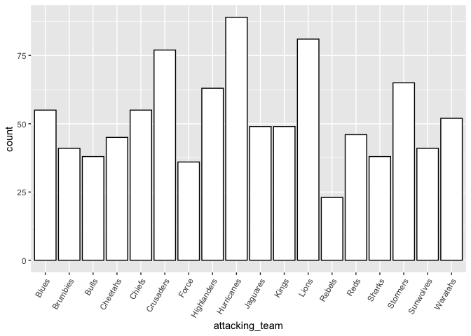

```r
ggplot(data = df) +
  geom_bar(mapping = aes(x = attacking_team), stat = "count", colour = "black", fill = "white") + theme(axis.text.x = element_text(angle = 60, hjust = 1))
```

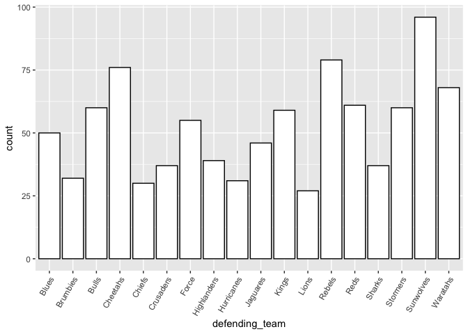

```r
ggplot(data = df) +
  geom_bar(mapping = aes(x = defending_team), stat = "count", colour = "black", fill = "white") + theme(axis.text.x = element_text(angle = 60, hjust = 1))
```

## Recording phases

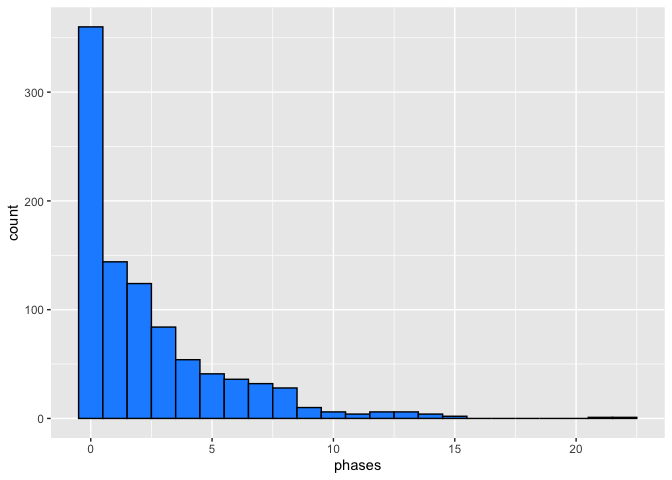

```r
ggplot(data = df) +
geom_histogram(mapping = aes(x = phases), colour = "black", fill = "dodgerblue", binwidth = 1)
```

## Time from Source

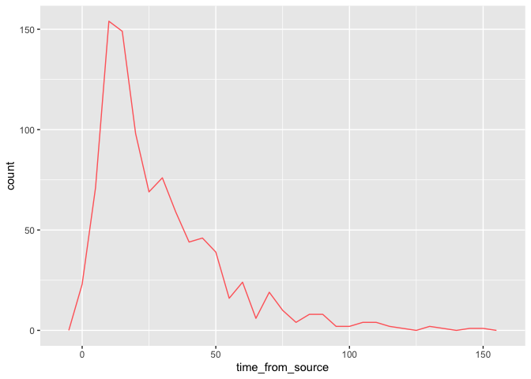

```r
ggplot(data = df) +
geom_freqpoly(mapping = aes(x = time_from_source), colour = "indianred1", binwidth = 5)
```

## Final Source

The two scatterplots are just to give a basic indication of how many passes are associated with each final source and try source with the colours representing each individual team, so the viewer can identify the different team plays.

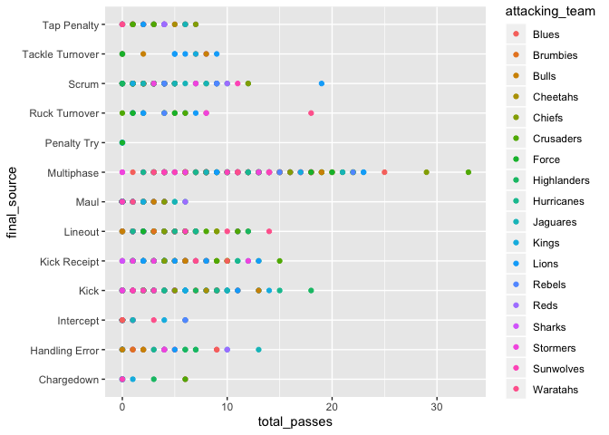

```r
ggplot(data = df) +
geom_point(mapping = aes(x = total_passes, y = final_source, colour = attacking_team))
```

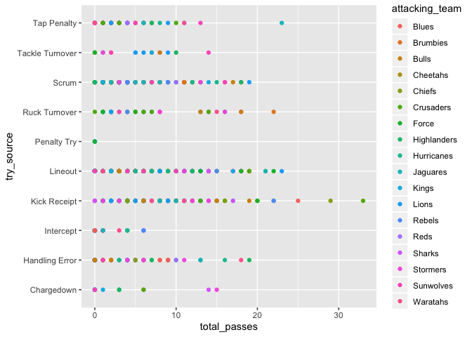

```r
ggplot(data = df) +
geom_point(mapping = aes(x = total_passes, y = try_source, colour = attacking_team))
```

## Attacking and defensive statistics

Just a basic graph to show which teams are ranked where on the attacking and defensive ends.

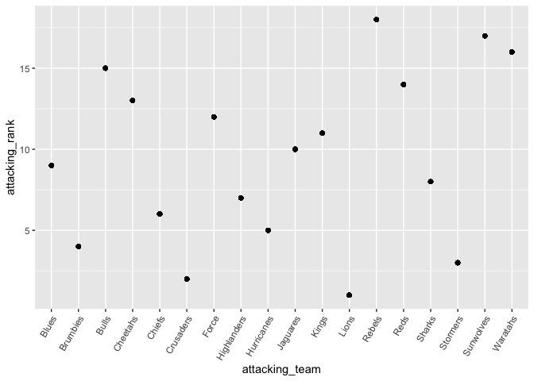

```r
ggplot(data = df) +
geom_point(mapping = aes(x = attacking_team, y = attacking_rank), arrange(df, attacking_team, attacking_rank)) + theme(axis.text.x = element_text(angle = 60, hjust = 1))
```

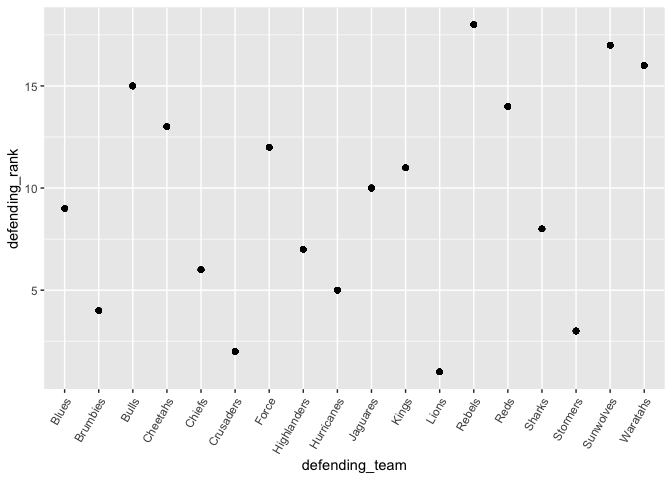

```r
ggplot(data = df) +
geom_point(mapping = aes(x = defending_team, y = defending_rank)) + theme(axis.text.x = element_text(angle = 60, hjust = 1)) + theme(axis.text.x = element_text(angle = 60, hjust = 1))
```

## Offloads and Total passes relationship

In this scatterplot, we can identify a small positive linear relationship between total offloads and the total amount of passes in a try scoring play

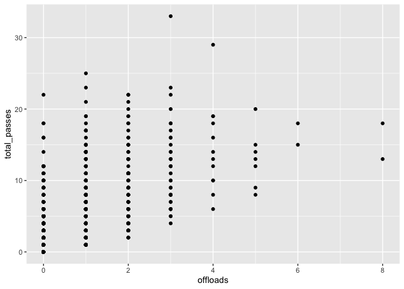

```r
ggplot(data = df) +
geom_point(mapping = aes(x = offloads, y = total_passes))
```

## Total passes and Try Source

It can be a good indication of how much passing is requiring to score a try from a particular source, a penalty try for example doesn’t require any.

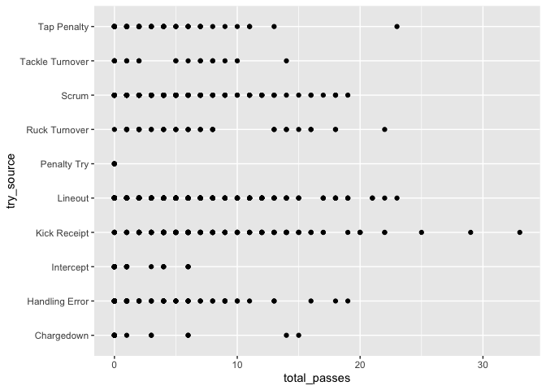

```r
ggplot(data = df) +
geom_point(mapping = aes(x = total_passes, y = try_source))
```

## Attacking team Game Time boxplot

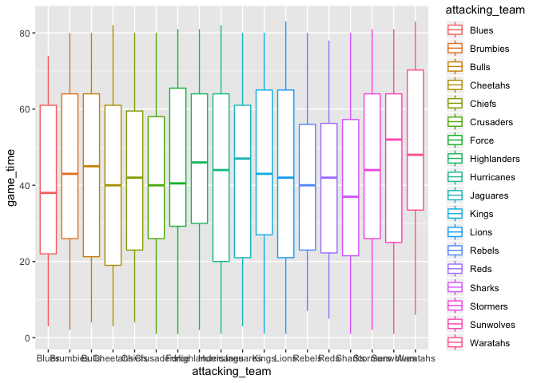

```r
ggplot(data = df) +
geom_boxplot(mapping = aes(x = attacking_team, y = game_time, colour = attacking_team))
```

## Possession zone and time from source boxplot

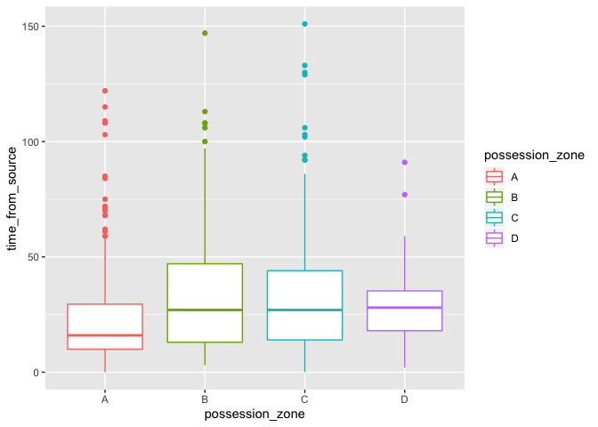

```r
ggplot(data = df) +
geom_boxplot(mapping = aes(x = possession_zone, y = time_from_source, colour = possession_zone))
```

## Boxplot of each attacking conference

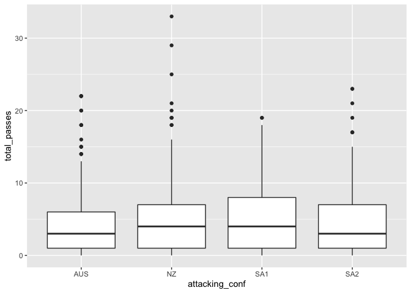

```r
ggplot(data = df) +
geom_boxplot(mapping = aes(x = attacking_conf, y = total_passes))
```